# 6_ml.R

dhicks1

Sat Apr 29 19:34:52 2017

This script constructs a machine learning model to predict comment valences (supporting or opposed to the use of glyphosate), then analyzes the terms that contribute to this prediction.

```r
library(caret)
library(randomForest)
library(pdp)

library(tidyverse)
library(tidytext)
library(stringr)

## Using a parallel backend speeds up fitting the random forest model
library(doSNOW)
cl = parallel::makeCluster(parallel::detectCores())
registerDoSNOW(cl)
```

First we load the data and construct a vocabulary. In this version of the script we use tf-idf. Future versions might use information gain or likelihood ratios.

```r
## Load tokens
load('4_tokens_df.Rdata')
table(tokens_df$valence, useNA = 'ifany')
```

```
##
##    neg    pos   <NA>
## 238196 123665   1100
```

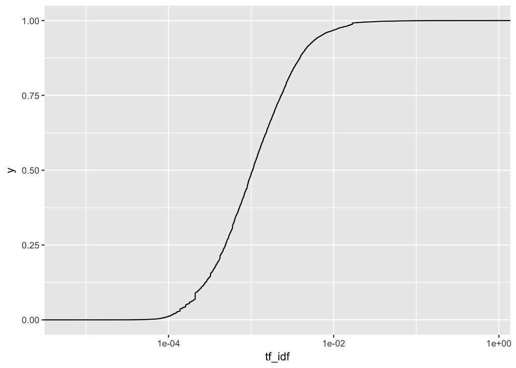

```r
tokens_df %>%
    filter(commenter_type %in% c('advocacy', 'industry'),
           !is.na(valence),
           str_detect(token, '[a-z]+')) -> tokens_df

## Construct token counts and calculate tf-idf across comments
token_n_df = tokens_df %>%
    group_by(comment_id, valence, token) %>%
    summarize(token_n = n()) %>%
    ungroup() %>%
    bind_tf_idf(token, comment_id, token_n)

## Plot tf-idf
ggplot(token_n_df, aes(tf_idf)) + stat_ecdf() + scale_x_log10()
```

```r
## Subset based on tf-idf
## In a real project, we'd probably do more robust feature selection here.
terms = token_n_df %>%
    arrange(desc(tf_idf)) %>%
    slice(1:2000) %>%
    .$token %>%
    unique()

str(terms)
```

```
##  chr [1:886] "see_attached_see_attached" "see_attached_file_s" ...
```

```r
## Spread token counts across comments
token_n_df %>%
    filter(token %in% terms) %>%
    select(comment_id, valence, token, token_n) %>%
    spread(token, token_n, fill = 0) -> token_n_df
token_n_df
```

```
## # A tibble: 106 × 888
##                   comment_id valence `_intro` `0385_dear`
## *                      <chr>   <chr>    <dbl>       <dbl>
## 1  EPA-HQ-OPP-2016-0385-0005     pos        0           0
## 2  EPA-HQ-OPP-2016-0385-0011     pos        0           0
## 3  EPA-HQ-OPP-2016-0385-0012     neg        0           0
## 4  EPA-HQ-OPP-2016-0385-0101     neg        0           0
## 5  EPA-HQ-OPP-2016-0385-0124     neg        0           0
## 6  EPA-HQ-OPP-2016-0385-0191     neg        0           0
## 7  EPA-HQ-OPP-2016-0385-0221     pos        0           0
## 8  EPA-HQ-OPP-2016-0385-0260     neg        0           0
## 9  EPA-HQ-OPP-2016-0385-0338     pos        0           0
## 10 EPA-HQ-OPP-2016-0385-0344     pos        0           0
## # ... with 96 more rows, and 884 more variables:
## #   `0385_dear_mr_knott` <dbl>, `10_key_characteristics` <dbl>,
## #   `14480e45fa5ca0522865d765eec6bb72` <dbl>, `1x` <dbl>, `2,4_d` <dbl>,
## #   `680_attachments_original` <dbl>, a_copy <dbl>, absorb <dbl>,
## #   access <dbl>, account <dbl>, acid <dbl>, acid_ampa <dbl>,
## #   acoustictracks.net <dbl>, across <dbl>, across_america <dbl>,
## #   act <dbl>, action <dbl>, action_network <dbl>, additional <dbl>,
## #   addresses <dbl>, advisor <dbl>, afbf <dbl>, affairs <dbl>, ag <dbl>,
## #   agency <dbl>, aggregate <dbl>, agree <dbl>, agree_with <dbl>,
## #   agri <dbl>, agricultural_sustainability <dbl>,
## #   agricultural_workers <dbl>, agriculture <dbl>, al <dbl>,
## #   alleging <dbl>, allergies <dbl>, am <dbl>, amazonaws.com <dbl>,
## #   amelia <dbl>, america <dbl>, american <dbl>, american_people <dbl>,
## #   americans <dbl>, americas <dbl>, amino <dbl>, amino_acid <dbl>,
## #   aminomethylphosphoric <dbl>, ampa <dbl>, an <dbl>,
## #   an_antibiotic <dbl>, anal <dbl>, analysis <dbl>, analyst <dbl>,
## #   anderson <dbl>, anderson.neil <dbl>, anthony <dbl>,
## #   anthony_samsel <dbl>, antibiotic <dbl>, any_amount <dbl>, apart <dbl>,
## #   apart_from <dbl>, applications <dbl>, approve <dbl>, apvma <dbl>,
## #   ara <dbl>, aradc.org <dbl>, asa <dbl>, assay <dbl>, assume_that <dbl>,
## #   at <dbl>, attach <dbl>, attached <dbl>, attached_file <dbl>,
## #   attached_letters <dbl>, attachments <dbl>, attachments_original <dbl>,
## #   attention <dbl>, autism <dbl>, autoimmune <dbl>,
## #   autoimmune_diseases <dbl>, available_at <dbl>, baby <dbl>,
## #   backing <dbl>, barley <dbl>, base.be <dbl>, bayer <dbl>,
## #   be_heard_as <dbl>, because <dbl>, beer <dbl>, beet <dbl>,
## #   behalf <dbl>, beings <dbl>, believes <dbl>, bellé <dbl>, below <dbl>,
## #   benefits_we_think <dbl>, benzene <dbl>, best <dbl>, beyond <dbl>,
## #   bfreese <dbl>, bill <dbl>, ...
```

Next we fit the machine learning model. To estimate out-of-model error, we first partition the data into training and testing sets.

```r
## Partition training and testing sets
set.seed(1234)
in_train = createDataPartition(token_n_df$valence, p = .5,
                               list = TRUE)$Resample1
token_n_df %>%
    mutate(training = row_number() %in% in_train) %>%
    select(comment_id, training, valence, everything()) ->
    token_n_df
training = token_n_df %>%
    filter(training) %>%
    select(-comment_id, -training)
testing = token_n_df %>%
    filter(!training) %>%
    select(-comment_id, -training)

## Fit the model
set.seed(113355)
rf_control = trainControl(# 10-fold crossvalidation
    method = 'cv',
    n = 10,
    classProbs = TRUE,
    # use the doSNOW parallel backend
    allowParallel = TRUE
)
rf_grid = tibble(mtry = 2^seq(1, 9, by = 2))
system.time(
    rf_fit <- train(x = training[-1],
                    y = training$valence,
                    tuneGrid = rf_grid,
                    trControl = rf_control,
                    method = 'rf')
)
```

```
##    user  system elapsed
##   1.387   0.038  18.484
```

```r
rf_fit
```

```
## Random Forest
##
##  53 samples
## 886 predictors
##   2 classes: 'neg', 'pos'
##
## No pre-processing
## Resampling: Cross-Validated (10 fold)
## Summary of sample sizes: 49, 47, 47, 48, 47, 47, ...
## Resampling results across tuning parameters:
##
##   mtry  Accuracy   Kappa
##     2   0.7266667  0.4878788
##     8   0.7633333  0.5343989
##    32   0.8400000  0.6776224
##   128   0.7883333  0.5843989
##   512   0.8050000  0.6177323
##
## Accuracy was used to select the optimal model using  the largest value.
## The final value used for the model was mtry = 32.
```

```r
## In-sample error
confusionMatrix(rf_fit)
```

```
## Cross-Validated (10 fold) Confusion Matrix
##
## (entries are percentual average cell counts across resamples)
##
##           Reference
## Prediction  neg  pos
##        neg 35.8  3.8
##        pos 11.3 49.1
##
##  Accuracy (average) : 0.8491
```